# Chapter 2 Data Preprocessing

Data preprocessing is the process of transforming raw data into a clean, consistent, and well-structured format suitable for building predictive models and machine learning algorithms. As the first and one of the most critical steps in the modeling pipeline, it directly influences model accuracy, efficiency, and overall performance.

## a. Data Cleaning and Formatting

It is essential to clean the data, correct inconsistencies, and organize it into a properly formatted structure before applying any modeling techniques.

## b. Handling Missing Values

Missing values can bias results or reduce efficiency. Strategies include:

- Imputation (mean/median/mode replacement, regression methods, KNN imputation)
- Removing incomplete records (if appropriate)

## c. Normalization and Scaling

Numerical features often need to be scaled to ensure fair contribution in model training. For example:

- **MinMaxScaler** rescales each feature to lie within `[0, 1]`.
- This is particularly effective when features are on very different scales and when using algorithms sensitive to feature magnitude (e.g., k-nearest neighbors, neural networks).

*Terminology:* Independent variables are also referred to as **predictors** or **features**.

## d. Encoding Categorical Variables (Dummy Variables)

Categorical variables must be converted into numeric form for most machine learning algorithms.

- A dummy variable assigns a numeric code (`0` or `1`) to indicate category membership.
- Each category of the original feature becomes a new binary variable.

## e. Feature Engineering and Selection

- **Feature engineering:** creating new features from existing ones (e.g., binning continuous variables, generating polynomial features).
- **Feature selection:** choosing the most relevant predictors automatically or manually to reduce noise and improve generalization.

## f. Handling Non-Normality

Some models assume normality of features. Transformations such as:

- **Power transformation**
- **Box-Cox transformation** (for positive values)

These methods can help stabilize variance and approximate normality.

## g. Dimensionality Reduction

Techniques like **Principal Component Analysis (PCA)** reduce the number of features while preserving most of the data’s variance. This improves computational efficiency and reduces overfitting.

## h. Learned Embeddings

For complex data types such as text, learned embeddings (e.g., word embeddings from deep learning models) provide dense, informative numerical representations. They are dense, low-dimensional vector representations of high-dimensional or categorical data, where the values are automatically learned by a machine learning model rather than manually engineered. They capture semantic or structural relationships between data points, making them highly useful for predictive modeling.

## ...

### Case Study: Cell Segmentation in High-Content Screening

The **`segmentationOriginal`** dataset from the `AppliedPredictiveModeling` package is a well-known example for image segmentation classification tasks.

- **Context:** The dataset arises from high-content screening experiments, where automated imaging is used to capture and analyze cells.
- **Predictors:** It includes a wide range of variables derived from cell images, such as shape, texture, and intensity measurements.
- **Response Variable:** Each observation is labeled as either **"PS" (well-segmented)** or **"WS" (poorly segmented)**, indicating the quality of the cell segmentation.

This dataset serves as a benchmark for developing and testing predictive models in biomedical image analysis.

```r
#Data preprocessing dataset

library(AppliedPredictiveModeling)
data(segmentationOriginal)

#To see the variables
str(segmentationOriginal)


dat =segmentationOriginal
# Many variables
```

```
'data.frame':	2019 obs. of  119 variables:
 $ Cell                         : int  207827637 207932307 207932463 207932470 207932455 207827656 207827659 207827661 207932479 207932480 ...
 $ Case                         : Factor w/ 2 levels "Test","Train": 1 2 2 2 1 1 1 1 1 1 ...
 $ Class                        : Factor w/ 2 levels "PS","WS": 1 1 2 1 1 2 2 1 2 2 ...
 $ AngleCh1                     : num  143.25 133.75 106.65 69.15 2.89 ...
 $ AngleStatusCh1               : int  1 0 0 0 2 2 1 1 2 1 ...
 $ AreaCh1                      : int  185 819 431 298 285 172 177 251 495 384 ...
 $ AreaStatusCh1                : int  0 1 0 0 0 0 0 0 0 0 ...
 $ AvgIntenCh1                  : num  15.7 31.9 28 19.5 24.3 ...
 $ AvgIntenCh2                  : num  3.95 205.88 115.32 101.29 111.42 ...
 $ AvgIntenCh3                  : num  9.55 69.92 63.94 28.22 20.47 ...
 $ AvgIntenCh4                  : num  2.21 164.15 106.7 31.03 40.58 ...
 $ AvgIntenStatusCh1            : int  0 0 0 0 0 1 1 0 0 0 ...
 $ AvgIntenStatusCh2            : int  2 0 0 0 0 1 1 2 0 0 ...
 $ AvgIntenStatusCh3            : int  2 0 0 0 0 1 1 0 0 0 ...
```

[output cut: 86 more lines]

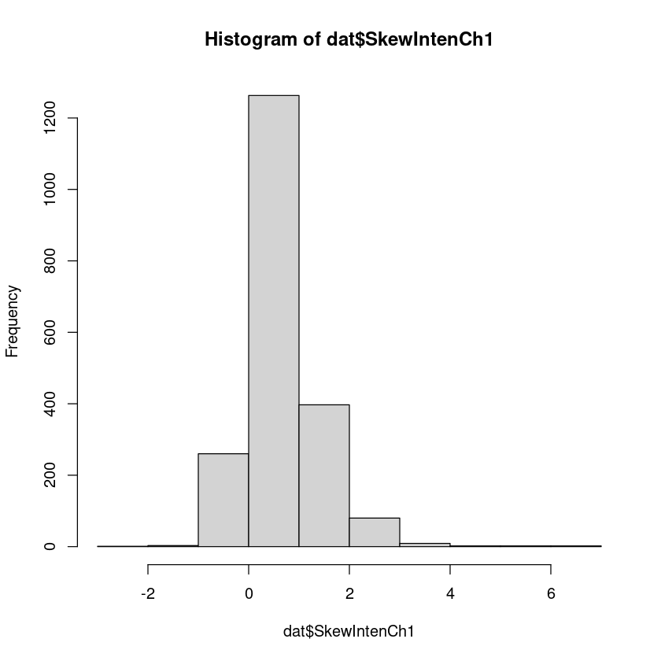

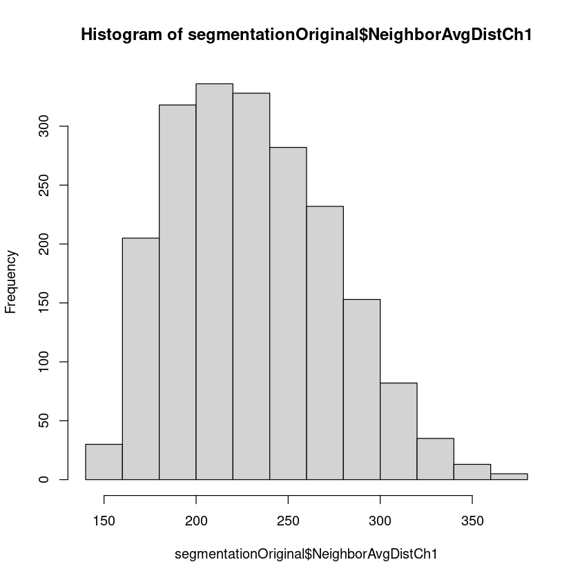

```r
# Data Transformations for Individual Predictors
# Histogram
# Mean, variance,
# Skewness,  kurtosis

hist(dat$SkewIntenCh1)

hist(segmentationOriginal$ NeighborAvgDistCh1)
```

The sample skewness = $$ \frac{\sum (x_i- \bar {x})^3} {n s^3} $$

If the sample skewness is close to zero, maybe the data are symmetrical.

If the sample skewness is much bigger than zero, the data are postively skewed/skewed to the right.

If the sample skewness is much below than zero, the data are negatively skewed/skewed to the left.

```r
#Self defined function in R:
#To find the skewness of a variable x
  skewfun = function(x)
  {
     xbar = mean(x)
     s = sd(x)
     n = length(x)
     sk = sum((x - xbar)^3)/(n*s^3)
     return(sk)
  }


#To find the skewness of SkewIntenCh1 using skewfun
  round(skewfun(segmentationOriginal$ SkewIntenCh1), 3)

#1.543:  postively skewed

#To find skewness of NeighborAvgDistCh1
  round(skewfun(segmentationOriginal$ NeighborAvgDistCh1), 2)
```

1.543

0.42

Output: The skewness statistic measures the asymmetry of the distribution of x.

Interpretation:

Skewness ≈ 0 → distribution is roughly symmetric.

Positive skewness → long right tail.

Negative skewness → long left tail.

```r
# use skewness calcualtion in package "e1071"

library(e1071)
#More reliable
skewness(dat$ SkewIntenCh1)
```

1.54284418741788

```r
head(dat[,3:20])
```

A data.frame: 6 × 18

|  | Class <fct> | AngleCh1 <dbl> | AngleStatusCh1 <int> | AreaCh1 <int> | AreaStatusCh1 <int> | AvgIntenCh1 <dbl> | AvgIntenCh2 <dbl> | AvgIntenCh3 <dbl> | AvgIntenCh4 <dbl> | AvgIntenStatusCh1 <int> | AvgIntenStatusCh2 <int> | AvgIntenStatusCh3 <int> | AvgIntenStatusCh4 <int> | ConvexHullAreaRatioCh1 <dbl> | ConvexHullAreaRatioStatusCh1 <int> | ConvexHullPerimRatioCh1 <dbl> | ConvexHullPerimRatioStatusCh1 <int> | DiffIntenDensityCh1 <dbl> |
| --- | --- | --- | --- | --- | --- | --- | --- | --- | --- | --- | --- | --- | --- | --- | --- | --- | --- | --- |
| 1 | PS | 143.247705 | 1 | 185 | 0 | 15.71186 | 3.954802 | 9.548023 | 2.214689 | 0 | 2 | 2 | 2 | 1.124509 | 0 | 0.9196827 | 0 | 29.51923 |
| 2 | PS | 133.752037 | 0 | 819 | 1 | 31.92327 | 205.878517 | 69.916880 | 164.153453 | 0 | 0 | 0 | 0 | 1.263158 | 1 | 0.7970801 | 2 | 31.87500 |
| 3 | WS | 106.646387 | 0 | 431 | 0 | 28.03883 | 115.315534 | 63.941748 | 106.696602 | 0 | 0 | 0 | 0 | 1.053310 | 0 | 0.9354750 | 0 | 32.48771 |
| 4 | PS | 69.150325 | 0 | 298 | 0 | 19.45614 | 101.294737 | 28.217544 | 31.028070 | 0 | 0 | 0 | 2 | 1.202625 | 0 | 0.8658291 | 2 | 26.73228 |
| 5 | PS | 2.887837 | 2 | 285 | 0 | 24.27574 | 111.415441 | 20.474265 | 40.577206 | 0 | 0 | 0 | 0 | 1.109333 | 0 | 0.9568124 | 0 | 31.58065 |
| 6 | WS | 40.748298 | 2 | 172 | 0 | 325.93333 | 652.606061 | 128.690909 | 346.854545 | 1 | 1 | 1 | 1 | 1.005831 | 0 | 0.9926363 | 1 | 92.56291 |

```r
#R apply function
#Example :  to calculate the skewness of the 3rd to 50th quantitative variables in the data

#The 3 rd quantitive variable is at the 9th column,
 # segmentationOriginal[, 9:50] data matrix
 # 2 : for a column
#apply(dat[, 9:100], 2, skewness )


#as.vector(round( apply(segmentationOriginal[, 9:50], 2, skewness ), 2))
round(apply(dat[, 9:50], 2, skewness ),3)
```

**AvgIntenCh2**

0.978

**AvgIntenCh3**

2.717

**AvgIntenCh4**

1.825

**AvgIntenStatusCh1**

1.529

**AvgIntenStatusCh2**

0.906

**AvgIntenStatusCh3**

3.013

**AvgIntenStatusCh4**

2.221

**ConvexHullAreaRatioCh1**

2.462

**ConvexHullAreaRatioStatusCh1**

3.089

**ConvexHullPerimRatioCh1**

-1.314

**ConvexHullPerimRatioStatusCh1**

1.569

**DiffIntenDensityCh1**

2.668

**DiffIntenDensityCh3**

2.067

**DiffIntenDensityCh4**

1.82

**DiffIntenDensityStatusCh1**

1.869

**DiffIntenDensityStatusCh3**

1.445

**DiffIntenDensityStatusCh4**

1.574

**EntropyIntenCh1**

0.366

**EntropyIntenCh3**

-0.999

**EntropyIntenCh4**

-0.832

**EntropyIntenStatusCh1**

0.731

**EntropyIntenStatusCh3**

0.841

**EntropyIntenStatusCh4**

1.103

**EqCircDiamCh1**

1.976

**EqCircDiamStatusCh1**

2.49

**EqEllipseLWRCh1**

2.569

**EqEllipseLWRStatusCh1**

2.506

**EqEllipseOblateVolCh1**

5.428

**EqEllipseOblateVolStatusCh1**

3.53

**EqEllipseProlateVolCh1**

5.395

**EqEllipseProlateVolStatusCh1**

3.966

**EqSphereAreaCh1**

3.368

**EqSphereAreaStatusCh1**

3.088

**EqSphereVolCh1**

5.301

**EqSphereVolStatusCh1**

3.82

**FiberAlign2Ch3**

-0.065

**FiberAlign2Ch4**

-0.116

**FiberAlign2StatusCh3**

1.034

**FiberAlign2StatusCh4**

0.746

**FiberLengthCh1**

2.293

**FiberLengthStatusCh1**

2.848

**FiberWidthCh1**

0.981

```r
library(knitr)

# Apply skewness function across variables 9-50
skew_vals = apply(dat[, 9:50], 2, skewness)

# Round and convert to data frame
skew.dat = data.frame(
  Variable = names(skew_vals),
  Skewness = round(skew_vals, 5),
  row.names = NULL
)

kable(skew.dat, align = "lc", caption = "Skewness of Selected Variables")
```

```
Table: Skewness of Selected Variables

|Variable                      | Skewness |
|:-----------------------------|:--------:|
|AvgIntenCh2                   | 0.97769  |
|AvgIntenCh3                   | 2.71683  |
|AvgIntenCh4                   | 1.82475  |
|AvgIntenStatusCh1             | 1.52938  |
|AvgIntenStatusCh2             | 0.90591  |
|AvgIntenStatusCh3             | 3.01277  |
|AvgIntenStatusCh4             | 2.22077  |
|ConvexHullAreaRatioCh1        | 2.46192  |
|ConvexHullAreaRatioStatusCh1  | 3.08907  |
|ConvexHullPerimRatioCh1       | -1.31388 |
|ConvexHullPerimRatioStatusCh1 | 1.56909  |
|DiffIntenDensityCh1           | 2.66778  |
|DiffIntenDensityCh3           | 2.06717  |
|DiffIntenDensityCh4           | 1.81997  |
|DiffIntenDensityStatusCh1     | 1.86865  |
|DiffIntenDensityStatusCh3     | 1.44538  |
|DiffIntenDensityStatusCh4     | 1.57378  |
|EntropyIntenCh1               | 0.36556  |
|EntropyIntenCh3               | -0.99902 |
|EntropyIntenCh4               | -0.83210 |
|EntropyIntenStatusCh1         | 0.73125  |
|EntropyIntenStatusCh3         | 0.84143  |
|EntropyIntenStatusCh4         | 1.10278  |
|EqCircDiamCh1                 | 1.97637  |
|EqCircDiamStatusCh1           | 2.48969  |
|EqEllipseLWRCh1               | 2.56913  |
|EqEllipseLWRStatusCh1         | 2.50553  |
|EqEllipseOblateVolCh1         | 5.42784  |
|EqEllipseOblateVolStatusCh1   | 3.53031  |
|EqEllipseProlateVolCh1        | 5.39470  |
|EqEllipseProlateVolStatusCh1  | 3.96580  |
|EqSphereAreaCh1               | 3.36786  |
|EqSphereAreaStatusCh1         | 3.08804  |
|EqSphereVolCh1                | 5.30097  |
|EqSphereVolStatusCh1          | 3.82037  |
|FiberAlign2Ch3                | -0.06489 |
|FiberAlign2Ch4                | -0.11587 |
|FiberAlign2StatusCh3          | 1.03405  |
|FiberAlign2StatusCh4          | 0.74636  |
|FiberLengthCh1                | 2.29339  |
|FiberLengthStatusCh1          | 2.84792  |
|FiberWidthCh1                 | 0.98076  |
```

A data.frame: 42 × 2

|  | Variable <chr> | Skewness <dbl> |
| --- | --- | --- |
| 28 | EqEllipseOblateVolCh1 | 5.42784 |
| 30 | EqEllipseProlateVolCh1 | 5.39470 |
| 34 | EqSphereVolCh1 | 5.30097 |
| 31 | EqEllipseProlateVolStatusCh1 | 3.96580 |
| 35 | EqSphereVolStatusCh1 | 3.82037 |
| 29 | EqEllipseOblateVolStatusCh1 | 3.53031 |
| 32 | EqSphereAreaCh1 | 3.36786 |
| 9 | ConvexHullAreaRatioStatusCh1 | 3.08907 |
| 33 | EqSphereAreaStatusCh1 | 3.08804 |
| 6 | AvgIntenStatusCh3 | 3.01277 |
| 41 | FiberLengthStatusCh1 | 2.84792 |
| 2 | AvgIntenCh3 | 2.71683 |
| 12 | DiffIntenDensityCh1 | 2.66778 |
| 26 | EqEllipseLWRCh1 | 2.56913 |
| 27 | EqEllipseLWRStatusCh1 | 2.50553 |
| 25 | EqCircDiamStatusCh1 | 2.48969 |
| 8 | ConvexHullAreaRatioCh1 | 2.46192 |
| 40 | FiberLengthCh1 | 2.29339 |
| 7 | AvgIntenStatusCh4 | 2.22077 |
| 13 | DiffIntenDensityCh3 | 2.06717 |
| 24 | EqCircDiamCh1 | 1.97637 |
| 15 | DiffIntenDensityStatusCh1 | 1.86865 |
| 3 | AvgIntenCh4 | 1.82475 |
| 14 | DiffIntenDensityCh4 | 1.81997 |
| 17 | DiffIntenDensityStatusCh4 | 1.57378 |
| 11 | ConvexHullPerimRatioStatusCh1 | 1.56909 |
| 4 | AvgIntenStatusCh1 | 1.52938 |
| 16 | DiffIntenDensityStatusCh3 | 1.44538 |
| 10 | ConvexHullPerimRatioCh1 | -1.31388 |
| 23 | EntropyIntenStatusCh4 | 1.10278 |
| 38 | FiberAlign2StatusCh3 | 1.03405 |
| 19 | EntropyIntenCh3 | -0.99902 |
| 42 | FiberWidthCh1 | 0.98076 |
| 1 | AvgIntenCh2 | 0.97769 |
| 5 | AvgIntenStatusCh2 | 0.90591 |
| 22 | EntropyIntenStatusCh3 | 0.84143 |
| 20 | EntropyIntenCh4 | -0.83210 |
| 39 | FiberAlign2StatusCh4 | 0.74636 |
| 21 | EntropyIntenStatusCh1 | 0.73125 |
| 18 | EntropyIntenCh1 | 0.36556 |
| 37 | FiberAlign2Ch4 | -0.11587 |
| 36 | FiberAlign2Ch3 | -0.06489 |

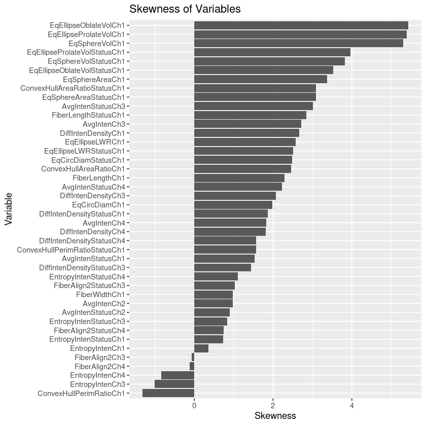

```r
#order
skew.dat[order(-abs(skew.dat$Skewness)), ]

library(ggplot2)
ggplot(skew.dat, aes(x = reorder(Variable, Skewness), y = Skewness)) +
  geom_bar(stat = "identity") +
  coord_flip() +
  labs(title = "Skewness of Variables", x = "Variable", y = "Skewness")
```

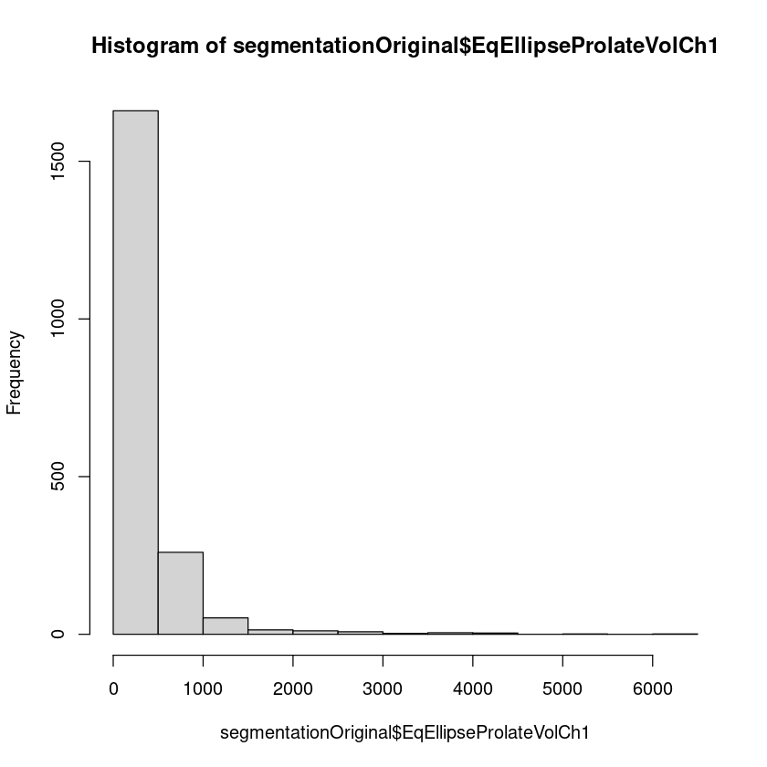

```r
#Suppose that we identify some variables with a large skewness ( highly skewed)
# For example EqEllipseProlateVolCh1 5.39
hist(segmentationOriginal$EqEllipseProlateVolCh1)
```

```r
#How to fix it for the purpose of predictive modeling
# Transformation on a single variable to fix "highly skewed " issue.
```

[figure not shown]

```r
# Histograms for all predictors (loop, auto layout)
# Histograms for 10th - 30 th variable
X = dat[, 10:30]
p = ncol(X)                      # number of predictors
nrow = ceiling(sqrt(p))          # rows
ncol = ceiling(p / nrow)         # columns

op = par(mfrow = c(nrow, ncol), mar = c(3.5, 3.5, 2, 1))
for (v in names(X)) {
  hist(X[[v]], breaks = "FD", main = v, xlab = "", ylab = "Count")
}
par(op)
```

# Power transfomation

Box-Cox transformation is a data science technique to transform a variable so that it resembles a normal distribution.

Plot the data/calcualte the skewness to see if the distribution of variables

# Formula:

$$ Y = \left \{ \begin{array}{l} { { \frac{X ^ \lambda - 1 } \lambda } \ \textrm{ for } \lambda \neq0, } \\ { { \mathop{\rm log} } X \ \textrm{ for } \lambda = 0. } \end{array} \right . $$

# package caret

-0.464646464646465

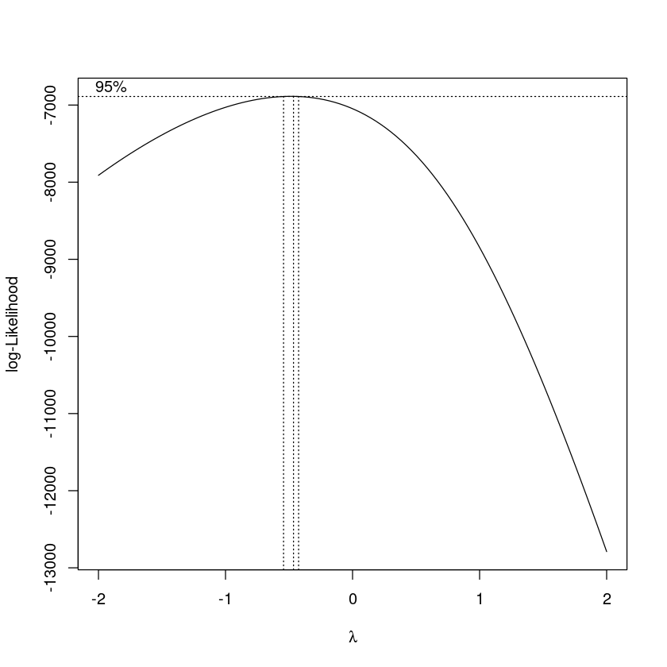

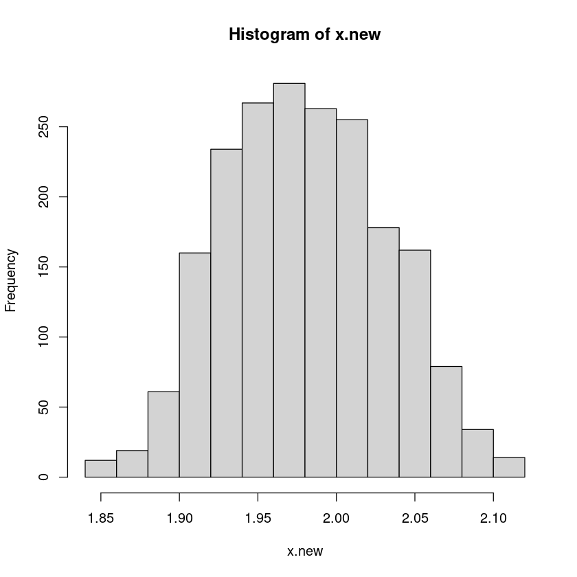

```r
#Load the package
library(MASS)
#Run boxcox transformation
yval = segmentationOriginal$EqEllipseProlateVolCh1
out = boxcox(yval ~ 1)

#To get the lambda to max the likelihood function as in the plot
lambda = out$x[out$y==max(out$y)]
lambda

#The power transformation (without )
x.new = ( yval^(lambda)  -1)/lambda          # the box-cox transformation
hist(x.new)
```

```r
# Load caret
library(caret)

# Suppose dat is your dataframe, with numeric column 'ca'
# Preprocess: apply Box-Cox transformation
#The input is a data frame
pp = preProcess(dat[, 35:43]  , method = "BoxCox")

# Inspect estimated lambda
pp$bc

# Apply the transformation to the data
dat_transformed <- predict(pp, dat[,35:43])

# Check results
head(dat_transformed)
```

```
$EqEllipseOblateVolCh1
Box-Cox Transformation

2019 data points used to estimate Lambda

Input data summary:
   Min. 1st Qu.  Median    Mean 3rd Qu.    Max.
  146.5   277.6   433.3   714.7   785.1 11689.0

Largest/Smallest: 79.8
Sample Skewness: 5.43

Estimated Lambda: -0.5


$EqEllipseProlateVolCh1
Box-Cox Transformation

2019 data points used to estimate Lambda

Input data summary:
   Min. 1st Qu.  Median    Mean 3rd Qu.    Max.
  63.85  148.36  224.36  361.57  383.89 6314.82

Largest/Smallest: 98.9
Sample Skewness: 5.39

Estimated Lambda: -0.5


$EqSphereAreaCh1
Box-Cox Transformation

2019 data points used to estimate Lambda

Input data summary:
   Min. 1st Qu.  Median    Mean 3rd Qu.    Max.
  603.8   775.7  1014.6  1283.4  1452.8  8746.1

Largest/Smallest: 14.5
Sample Skewness: 3.37

Estimated Lambda: -0.9


$EqSphereVolCh1
Box-Cox Transformation

2019 data points used to estimate Lambda

Input data summary:
   Min. 1st Qu.  Median    Mean 3rd Qu.    Max.
   1395    2031    3039    4918    5207   76912

Largest/Smallest: 55.1
Sample Skewness: 5.3

Estimated Lambda: -0.6
```

A data.frame: 6 × 9

|  | EqEllipseLWRStatusCh1 <int> | EqEllipseOblateVolCh1 <dbl> | EqEllipseOblateVolStatusCh1 <int> | EqEllipseProlateVolCh1 <dbl> | EqEllipseProlateVolStatusCh1 <int> | EqSphereAreaCh1 <dbl> | EqSphereAreaStatusCh1 <int> | EqSphereVolCh1 <dbl> | EqSphereVolStatusCh1 <int> |
| --- | --- | --- | --- | --- | --- | --- | --- | --- | --- |
| 1 | 1 | 1.891048 | 0 | 1.809391 | 0 | 1.108212 | 0 | 1.648700 | 0 |
| 2 | 0 | 1.957675 | 1 | 1.947164 | 1 | 1.110350 | 1 | 1.661949 | 1 |
| 3 | 0 | 1.929386 | 0 | 1.917186 | 0 | 1.109756 | 0 | 1.658268 | 0 |
| 4 | 1 | 1.925707 | 0 | 1.863188 | 0 | 1.109222 | 0 | 1.654964 | 0 |
| 5 | 0 | 1.918857 | 0 | 1.865651 | 0 | 1.109141 | 0 | 1.654462 | 0 |
| 6 | 0 | 1.849573 | 0 | 1.846614 | 0 | 1.108022 | 0 | 1.647528 | 0 |

# Find nearZero variance predictors

A nearZero variance predictor: if the variance is close to zero, the data values may be the same for most cases. All data values are the same : zero variance (almost zero variance if most of the values are the same, except a very few are different). Sometimes, the data may have predictors that only have a single unique value or might have only a few unique values that occur with exetreme low frequencies, which may cause some models to crash or the fit to be unstable.

function nearZeroVar (caret) Return the column numbers of any near-zero variance predictors

To identify these predictors, the following:

- the frequency of the most prevalent value over the second most frequent value (called the "frequency ratio''), which would be near one for well-behaved predictors and very large for highly-unbalanced data.
- the "percent of unique values'' is the number of unique values divided by the total number of samples that approaches zero as the granularity (the level of details) of the data increases.

If the frequency ratio is greater than a pre-specified threshold and the unique value percentage is less than a threshold, we might consider a predictor to be near zero-variance.

Example: nR11 varialbe in R dataset "mdrr" from caret package.

```r
#Subsetting the Data
#delete all Status variables
sdata = subset(segmentationOriginal, Case == "Train")

#sdata = segmentationOriginal[segmentationOriginal$Case == "Train",]
#sdata= segmentationOriginal%>%filter(Case == "Train")

cellid = sdata$Cell
class = sdata$Class
case = sdata$Case

#To delete the first three variables
segData = sdata[,-(1:3)]

#To select all variables such that the "Status" is in the name of the variable.
statusColNum = grep("Status", names(segData))

#Keep all variables which are quantitative (no status variables)
segData = segData[,-statusColNum]

#The number of cases and the number of variables
length(segData[,1])
length(segData[1,])

str(segData)
#There are still 58 vaiables

columns = nearZeroVar(segData, saveMetrics = TRUE)
```

1009

58

```
'data.frame':	1009 obs. of  58 variables:
 $ AngleCh1               : num  133.8 106.6 69.2 109.4 104.3 ...
 $ AreaCh1                : int  819 431 298 256 258 358 158 315 246 223 ...
 $ AvgIntenCh1            : num  31.9 28 19.5 18.8 17.6 ...
 $ AvgIntenCh2            : num  206 115 101 126 124 ...
 $ AvgIntenCh3            : num  69.9 63.9 28.2 13.6 22.5 ...
 $ AvgIntenCh4            : num  164.2 106.7 31 46.8 71.2 ...
 $ ConvexHullAreaRatioCh1 : num  1.26 1.05 1.2 1.08 1.08 ...
 $ ConvexHullPerimRatioCh1: num  0.797 0.935 0.866 0.92 0.931 ...
 $ DiffIntenDensityCh1    : num  31.9 32.5 26.7 28 27.9 ...
 $ DiffIntenDensityCh3    : num  43.1 36 22.9 14.9 16.1 ...
 $ DiffIntenDensityCh4    : num  79.3 51.4 26.4 32.7 36.2 ...
 $ EntropyIntenCh1        : num  6.09 5.88 5.42 5.38 5.18 ...
 $ EntropyIntenCh3        : num  6.64 6.68 5.44 4.15 5.49 ...
 $ EntropyIntenCh4        : num  7.88 7.14 5.78 6.19 6.62 ...
```

[output cut: 44 more lines]

```r
library(caret)

columns = nearZeroVar(segData, saveMetrics = TRUE)

columns
```

A data.frame: 58 × 4

|  | freqRatio <dbl> | percentUnique <dbl> | zeroVar <lgl> | nzv <lgl> |
| --- | --- | --- | --- | --- |
| AngleCh1 | 1.000000 | 100.000000 | FALSE | FALSE |
| AreaCh1 | 1.181818 | 39.544103 | FALSE | FALSE |
| AvgIntenCh1 | 1.000000 | 100.000000 | FALSE | FALSE |
| AvgIntenCh2 | 2.000000 | 99.900892 | FALSE | FALSE |
| AvgIntenCh3 | 1.000000 | 100.000000 | FALSE | FALSE |
| AvgIntenCh4 | 1.000000 | 100.000000 | FALSE | FALSE |
| ConvexHullAreaRatioCh1 | 1.000000 | 99.108028 | FALSE | FALSE |
| ConvexHullPerimRatioCh1 | 1.000000 | 100.000000 | FALSE | FALSE |
| DiffIntenDensityCh1 | 1.000000 | 100.000000 | FALSE | FALSE |
| DiffIntenDensityCh3 | 1.000000 | 100.000000 | FALSE | FALSE |
| DiffIntenDensityCh4 | 1.000000 | 100.000000 | FALSE | FALSE |
| EntropyIntenCh1 | 1.000000 | 100.000000 | FALSE | FALSE |
| EntropyIntenCh3 | 1.000000 | 100.000000 | FALSE | FALSE |
| EntropyIntenCh4 | 1.000000 | 100.000000 | FALSE | FALSE |
| EqCircDiamCh1 | 1.181818 | 39.544103 | FALSE | FALSE |
| EqEllipseLWRCh1 | 1.000000 | 100.000000 | FALSE | FALSE |
| EqEllipseOblateVolCh1 | 1.000000 | 100.000000 | FALSE | FALSE |
| EqEllipseProlateVolCh1 | 1.000000 | 100.000000 | FALSE | FALSE |
| EqSphereAreaCh1 | 1.181818 | 39.544103 | FALSE | FALSE |
| EqSphereVolCh1 | 1.181818 | 39.544103 | FALSE | FALSE |
| FiberAlign2Ch3 | 1.200000 | 95.837463 | FALSE | FALSE |
| FiberAlign2Ch4 | 5.000000 | 94.251734 | FALSE | FALSE |
| FiberLengthCh1 | 1.000000 | 95.143707 | FALSE | FALSE |
| FiberWidthCh1 | 1.000000 | 95.143707 | FALSE | FALSE |
| IntenCoocASMCh3 | 1.000000 | 100.000000 | FALSE | FALSE |
| IntenCoocASMCh4 | 1.000000 | 100.000000 | FALSE | FALSE |
| IntenCoocContrastCh3 | 1.000000 | 100.000000 | FALSE | FALSE |
| IntenCoocContrastCh4 | 1.000000 | 100.000000 | FALSE | FALSE |
| IntenCoocEntropyCh3 | 1.000000 | 100.000000 | FALSE | FALSE |
| IntenCoocEntropyCh4 | 1.000000 | 100.000000 | FALSE | FALSE |
| IntenCoocMaxCh3 | 1.000000 | 92.269574 | FALSE | FALSE |
| IntenCoocMaxCh4 | 1.666667 | 95.143707 | FALSE | FALSE |
| KurtIntenCh1 | 1.000000 | 100.000000 | FALSE | FALSE |
| KurtIntenCh3 | 1.000000 | 100.000000 | FALSE | FALSE |
| KurtIntenCh4 | 1.000000 | 100.000000 | FALSE | FALSE |
| LengthCh1 | 1.000000 | 100.000000 | FALSE | FALSE |
| NeighborAvgDistCh1 | 1.000000 | 100.000000 | FALSE | FALSE |
| NeighborMinDistCh1 | 1.400000 | 42.220020 | FALSE | FALSE |
| NeighborVarDistCh1 | 1.000000 | 100.000000 | FALSE | FALSE |
| PerimCh1 | 1.166667 | 65.113974 | FALSE | FALSE |
| ShapeBFRCh1 | 1.000000 | 100.000000 | FALSE | FALSE |
| ShapeLWRCh1 | 1.000000 | 100.000000 | FALSE | FALSE |
| ShapeP2ACh1 | 2.000000 | 99.900892 | FALSE | FALSE |
| SkewIntenCh1 | 1.000000 | 100.000000 | FALSE | FALSE |
| SkewIntenCh3 | 1.000000 | 100.000000 | FALSE | FALSE |
| SkewIntenCh4 | 1.000000 | 100.000000 | FALSE | FALSE |
| SpotFiberCountCh3 | 1.047101 | 1.090188 | FALSE | FALSE |
| SpotFiberCountCh4 | 1.052980 | 3.072349 | FALSE | FALSE |
| TotalIntenCh1 | 1.000000 | 99.405352 | FALSE | FALSE |
| TotalIntenCh2 | 1.000000 | 99.008920 | FALSE | FALSE |
| TotalIntenCh3 | 1.000000 | 99.108028 | FALSE | FALSE |
| TotalIntenCh4 | 1.000000 | 99.108028 | FALSE | FALSE |
| VarIntenCh1 | 1.000000 | 100.000000 | FALSE | FALSE |
| VarIntenCh3 | 1.000000 | 100.000000 | FALSE | FALSE |
| VarIntenCh4 | 1.000000 | 100.000000 | FALSE | FALSE |
| WidthCh1 | 1.000000 | 100.000000 | FALSE | FALSE |
| XCentroid | 1.125000 | 41.625372 | FALSE | FALSE |
| YCentroid | 1.000000 | 35.877106 | FALSE | FALSE |

```r
#library(caret)
#
data(mdrr)
data.frame(table(mdrrDescr$nR11))
```

A data.frame: 3 × 2

| Var1 <fct> | Freq <int> |
| --- | --- |
| 0 | 501 |
| 1 | 4 |
| 2 | 23 |

```r
#str(mdrrDescr)
nvz0 = nearZeroVar(mdrrDescr, saveMetrics = TRUE)
#nvz.dat
#how many variables with near zero variance (nzv)
sum(nvz0$nzv==TRUE)

#To show what variables have near zero variance (nzv)
mdrrDescr[1,nvz0$nzv==TRUE]

nvz0
```

45

A data.frame: 1 × 45

|  | nTB <dbl> | nBR <dbl> | nI <dbl> | nR03 <dbl> | nR08 <dbl> | nR11 <dbl> | nR12 <dbl> | D.Dr03 <dbl> | D.Dr07 <dbl> | D.Dr08 <dbl> | ⋯ | G.O..Br. <dbl> | G.O..I. <dbl> | G.S..S. <dbl> | G.S..F. <dbl> | G.S..Cl. <dbl> | G.F..F. <dbl> | G.F..Cl. <dbl> | G.Cl..Cl. <dbl> | G.Cl..Br. <dbl> | G.I..I. <dbl> |
| --- | --- | --- | --- | --- | --- | --- | --- | --- | --- | --- | --- | --- | --- | --- | --- | --- | --- | --- | --- | --- | --- |
| METHOPROMAZINE | 0 | 0 | 0 | 0 | 0 | 0 | 0 | 0 | 0 | 0 | ⋯ | 0 | 0 | 0 | 0 | 0 | 0 | 0 | 0 | 0 | 0 |

A data.frame: 342 × 4

|  | freqRatio <dbl> | percentUnique <dbl> | zeroVar <lgl> | nzv <lgl> |
| --- | --- | --- | --- | --- |
| MW | 1.250000 | 89.9621212 | FALSE | FALSE |
| AMW | 1.125000 | 42.6136364 | FALSE | FALSE |
| Sv | 1.000000 | 82.9545455 | FALSE | FALSE |
| Se | 1.250000 | 84.2803030 | FALSE | FALSE |
| Sp | 1.250000 | 82.7651515 | FALSE | FALSE |
| Ss | 1.000000 | 71.2121212 | FALSE | FALSE |
| Mv | 1.084507 | 3.4090909 | FALSE | FALSE |
| Me | 1.176471 | 1.7045455 | FALSE | FALSE |
| Mp | 1.157143 | 3.7878788 | FALSE | FALSE |
| Ms | 1.125000 | 18.5606061 | FALSE | FALSE |
| nAT | 1.047619 | 13.6363636 | FALSE | FALSE |
| nSK | 1.111111 | 7.1969697 | FALSE | FALSE |
| nBT | 1.100000 | 12.8787879 | FALSE | FALSE |
| nBO | 1.000000 | 7.7651515 | FALSE | FALSE |
| nBM | 1.861111 | 4.5454545 | FALSE | FALSE |
| SCBO | 1.150000 | 15.5303030 | FALSE | FALSE |
| nCIC | 1.132867 | 1.1363636 | FALSE | FALSE |
| nCIR | 1.024590 | 2.6515152 | FALSE | FALSE |
| RBN | 1.021277 | 5.6818182 | FALSE | FALSE |
| RBF | 1.028571 | 6.0606061 | FALSE | FALSE |
| nDB | 1.666667 | 0.9469697 | FALSE | FALSE |
| nTB | 23.000000 | 0.3787879 | FALSE | TRUE |
| nAB | 4.680851 | 4.1666667 | FALSE | FALSE |
| nH | 1.111111 | 7.3863636 | FALSE | FALSE |
| nC | 1.195652 | 5.4924242 | FALSE | FALSE |
| nN | 1.036810 | 1.7045455 | FALSE | FALSE |
| nO | 1.092593 | 2.0833333 | FALSE | FALSE |
| nS | 7.354839 | 0.5681818 | FALSE | FALSE |
| nF | 16.206897 | 1.3257576 | FALSE | FALSE |
| nCL | 6.000000 | 0.9469697 | FALSE | FALSE |
| ⋮ | ⋮ | ⋮ | ⋮ | ⋮ |
| QZZv | 1.000000 | 99.4318182 | FALSE | FALSE |
| DISPe | 1.333333 | 46.7803030 | FALSE | FALSE |
| QXXe | 1.000000 | 99.4318182 | FALSE | FALSE |
| QYYe | 1.000000 | 99.4318182 | FALSE | FALSE |
| QZZe | 1.000000 | 99.4318182 | FALSE | FALSE |
| DISPp | 1.000000 | 73.4848485 | FALSE | FALSE |
| QXXp | 1.000000 | 99.4318182 | FALSE | FALSE |
| QYYp | 1.000000 | 99.0530303 | FALSE | FALSE |
| QZZp | 1.000000 | 99.4318182 | FALSE | FALSE |
| G.N..N. | 6.923077 | 38.0681818 | FALSE | FALSE |
| G.N..O. | 9.909091 | 68.7500000 | FALSE | FALSE |
| G.N..S. | 114.000000 | 11.5530303 | FALSE | FALSE |
| G.N..F. | 235.000000 | 10.2272727 | FALSE | FALSE |
| G.N..Cl. | 144.000000 | 17.2348485 | FALSE | FALSE |
| G.N..Br. | 262.000000 | 0.7575758 | FALSE | TRUE |
| G.N..I. | 527.000000 | 0.3787879 | FALSE | TRUE |
| G.O..O. | 35.000000 | 42.8030303 | FALSE | FALSE |
| G.O..S. | 161.000000 | 7.1969697 | FALSE | TRUE |
| G.O..F. | 158.666667 | 8.7121212 | FALSE | TRUE |
| G.O..Cl. | 150.666667 | 13.6363636 | FALSE | FALSE |
| G.O..Br. | 262.500000 | 0.5681818 | FALSE | TRUE |
| G.O..I. | 527.000000 | 0.3787879 | FALSE | TRUE |
| G.S..S. | 260.000000 | 1.3257576 | FALSE | TRUE |
| G.S..F. | 260.000000 | 1.5151515 | FALSE | TRUE |
| G.S..Cl. | 169.666667 | 2.6515152 | FALSE | TRUE |
| G.F..F. | 101.600000 | 3.2196970 | FALSE | TRUE |
| G.F..Cl. | 520.000000 | 1.7045455 | FALSE | TRUE |
| G.Cl..Cl. | 168.000000 | 3.5984848 | FALSE | TRUE |
| G.Cl..Br. | 527.000000 | 0.3787879 | FALSE | TRUE |
| G.I..I. | 527.000000 | 0.3787879 | FALSE | TRUE |

```r
#Excercise:  Find the number of variables with near zero variance in  mdrrDescr[, 30:70].

d0 =  mdrrDescr[, 30:70]
nvz0 = nearZeroVar(d0, saveMetrics = TRUE)

sum(nvz0$nzv==TRUE)
```

6

# Identify Highly Correlated Predictors

While there are some models that thrive on correlated predictors such as `pls`, many models may benefit from reducing the level of correlation between the predictors.

Correlation: $r$ (sample correlation). The correlation is always between -1 (perfectly negatively related) and 1 (perfectly positively related).

To detect highly correlated predictors, function "findCorrelation" returns column numbers denoting the predictors that are recommended for deletion.

Example: Find these highly correlated variables in data segData.

1. 58

2. 58

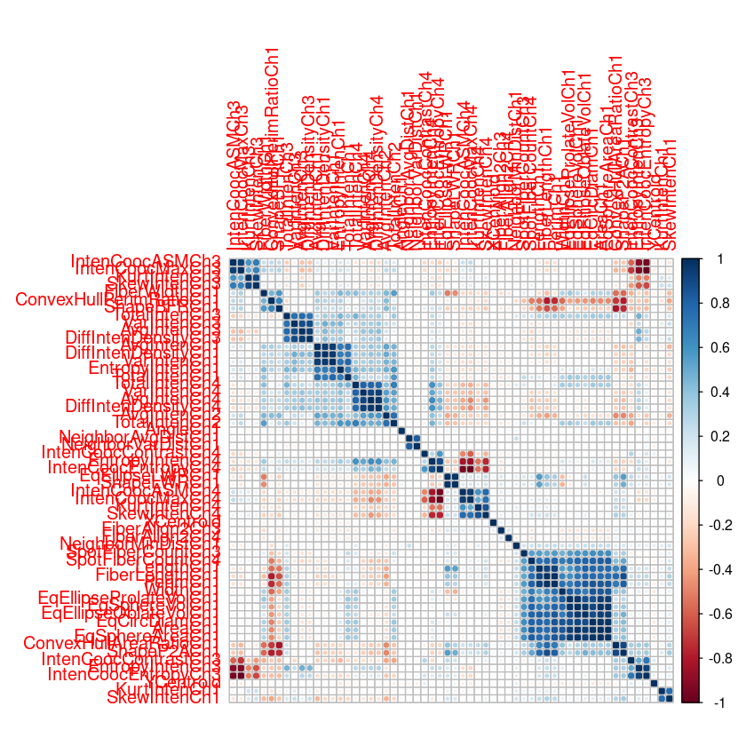

```r
#Calculate the correlation matrix
correlations = cor(segData)
dim(correlations)

#To make a correlation plot
library(corrplot)
corrplot(correlations, order = "hclust")
```

```r
#To find Highly Correlated Predictors with cutoff value 0.95
#returns the col numbers of variables which have high abs(correlation) values above the cutoff values
highCorr = findCorrelation(correlations, cutoff =.95)

highCorr

#Delete all variables which have a high correlation.
filteredSegData = segData[, -highCorr]
```

1. 23

2. 15

3. 19

4. 2

5. 17

6. 6

7. 20

8. 3

9. 9

10. 30

11. 29

12. 16

A data.frame: 1 × 12

|  | FiberLengthCh1 <dbl> | EqCircDiamCh1 <dbl> | EqSphereAreaCh1 <dbl> | AreaCh1 <int> | EqEllipseOblateVolCh1 <dbl> | AvgIntenCh4 <dbl> | EqSphereVolCh1 <dbl> | AvgIntenCh1 <dbl> | DiffIntenDensityCh1 <dbl> | IntenCoocEntropyCh4 <dbl> | IntenCoocEntropyCh3 <dbl> | EqEllipseLWRCh1 <dbl> |
| --- | --- | --- | --- | --- | --- | --- | --- | --- | --- | --- | --- | --- |
| 2 | 64.2823 | 32.30558 | 3278.726 | 819 | 2232.905 | 164.1535 | 17653.52 | 31.92327 | 31.875 | 7.098988 | 6.822138 | 1.558394 |

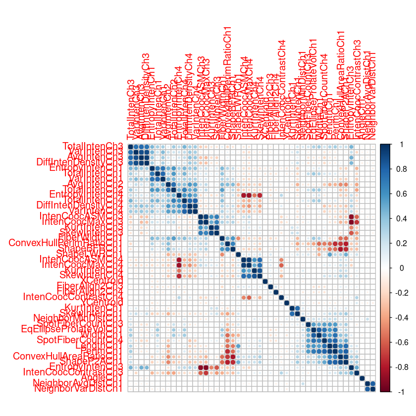

```r
#To show the variables with high correlation issues
segData[1, highCorr]


#Correlation plot for the filterdSegData
cor2 = cor(filteredSegData)

corrplot(cor2, order = "hclust")
```

# Transformation - standarization , scaling, normalization, ...

Sacling the data so that each feature is in the range [0,1] by minmax scaler. It works well when the features have different scales and the algorithm being used is sensitive to the scale of the features, such as k-nearest neighbors or neural networks.

Scaling and centering for an individual predictor (standarization): $z = \frac{(x- \bar {x})} {s}$ where x is a data value. This is the same the z-score of $x$.

R funcion:

```
  scaled.x = scale(x, center = TRUE, scale = TRUE)
```

1

0

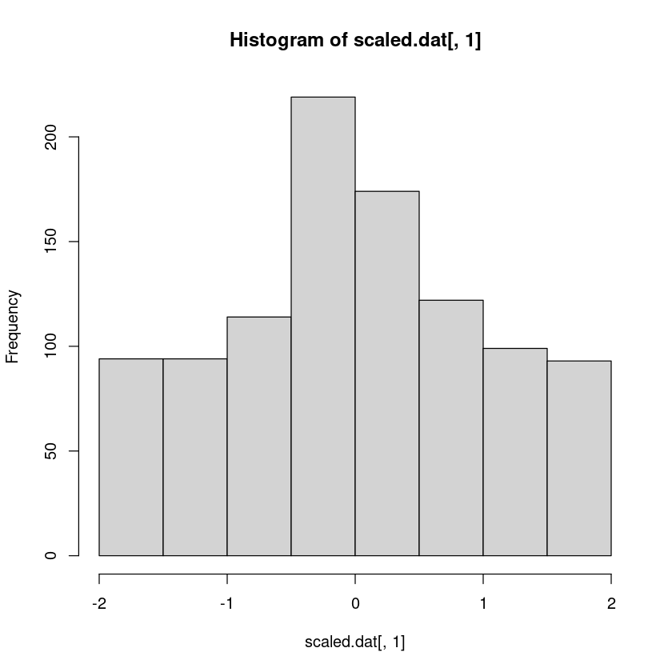

```r
# Scaling all variable in data set   "segData"
#the data such that all variables are standarized.
scaled.dat =  scale(segData, center = TRUE, scale = TRUE)


var(scaled.dat[,5])
round(mean(scaled.dat[,3]),5)

hist(scaled.dat[,1])


#minmax
```

# Data Transformations for Multiple Predictors

The focus of these transformations is to address outliers and reduce the dimensionality of the data, both of which are critical for improving the performance and interpretability of models.

Transformations to Resolve Outliers For models sensitive to outliers, the spatial sign transformation can be used to reduce their impact by focusing on the direction of the data instead of its magnitude.

Data Reduction and Feature Extraction Data reduction techniques are transformations that create a smaller set of predictors, aiming to retain most of the information from the original variables while reducing the overall data complexity.

Example: The "spatial sign" transformation (Serneels et al., 2006) projects predictor data onto the unit circle in p-dimensional space by dividing each data vector by its norm. Prior to this transformation, predictors need to be centered and scaled.

The two figures provided show the effect of this transformation on two centered and scaled descriptors from the MDRR data.

```r
library(caret)
```

```r
data(mdrr)
scaled.dat  =  scale(mdrrDescr[, c("nC", "X4v")])
plotSubset = data.frame(scaled.dat)

str(plotSubset)
```

```
'data.frame':	528 obs. of  2 variables:
 $ nC : num  -0.691 -0.494 -0.691 -0.888 -0.494 ...
 $ X4v: num  0.0146 0.1084 0.239 -0.234 -0.0264 ...
```

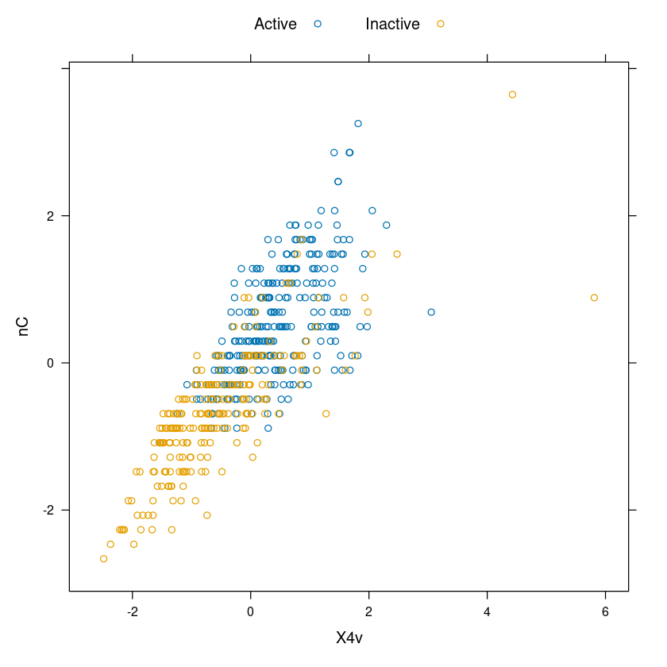

```r
#plot the data
xyplot(nC ~ X4v, data = plotSubset, groups = mdrrClass, auto.key = list(columns = 2))

#There are two outliers
```

```
'data.frame':	528 obs. of  2 variables:
 $ nC : num  -1 -0.977 -0.945 -0.967 -0.999 ...
 $ X4v: num  0.0212 0.2145 0.3269 -0.2548 -0.0534 ...
```

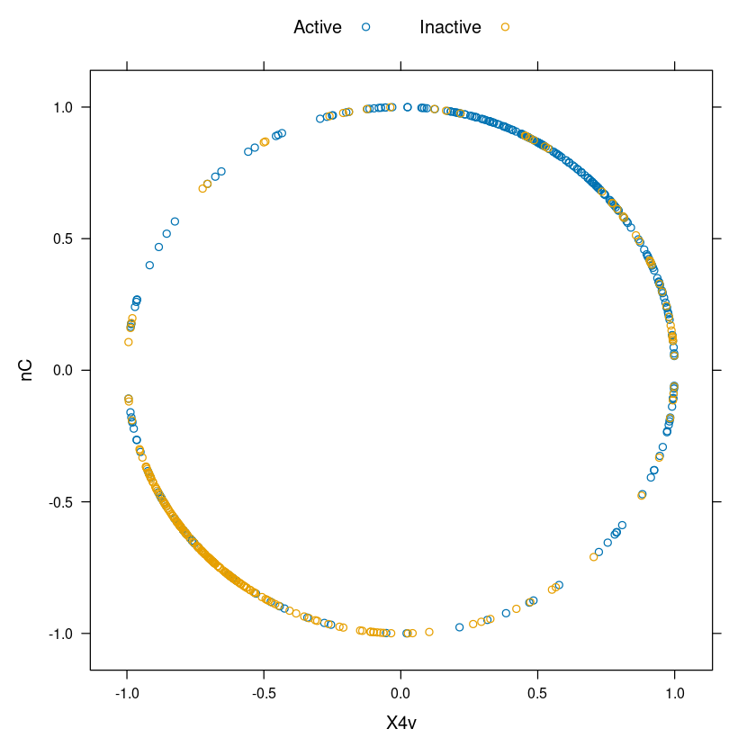

```r
#Spatial sign transformation
dat.transformed = spatialSign(plotSubset)
dat.transformed = as.data.frame(dat.transformed)
str(dat.transformed)
#plot the data
xyplot(nC ~ X4v, data = dat.transformed, groups = mdrrClass, auto.key = list(columns = 2))
```

```r
Excercise:  please run spatial sign transformation for variabless LengthCh1 and NeighborAvgDistCh1 of segmentationOriginal.
Please plot the data and the transformed data.
```

# Missing Values

If the pattern of missing data is related to the outcome, it is known as "informative missingness." This type of missingness can introduce significant bias into the model, as the missing data itself provides valuable information about the outcome.

In R, we can use the mice package (Multiple Imputation by Chained Equations) to perform both multiple imputation and the subsequent analysis. The mice() function carries out the imputation using chained equations. Without delving too deeply into the details, chained equations are a variant of the Gibbs Sampler, an MCMC (Markov Chain Monte Carlo) method. This approach iterates between estimating missing values and estimating parameters for the distribution of the variables, with both being conditional on the other variables. The number of imputations is controlled by the m argument, and the default value is set to 5.

```r
library(mice)
```

```r
#Load the data
loc = "diamond_MissingValues.csv"
dat = read.csv(loc, header=1)
head(dat, 10)
```

A data.frame: 10 × 10

|  | carat <dbl> | cut <chr> | color <chr> | clarity <chr> | depth <dbl> | table <dbl> | price <int> | x <dbl> | y <dbl> | z <dbl> |
| --- | --- | --- | --- | --- | --- | --- | --- | --- | --- | --- |
| 1 | 0.53 | Good | D | SI2 | 63.9 | 55 | 1318 | 5.14 | 5.10 | 3.27 |
| 2 | 0.42 | Premium | F | VS1 | 61.2 | 58 | 1103 | 4.86 | 4.82 | 2.96 |
| 3 | 0.34 | Premium | E | VS1 | 59.9 | 58 | 1033 | 4.58 | 4.54 | 2.73 |
| 4 | 0.70 | Very Good | D | VS1 | 62.8 | 59 | 3247 | 5.63 | 5.68 | 3.55 |
| 5 | 0.28 | Very Good | E | VVS2 | 64.0 | 54 | 572 | 4.11 | 4.17 | 2.65 |
| 6 | 0.51 | Premium | D | VS2 | 62.0 | 59 | 1807 | 5.12 | 5.08 | 3.16 |
| 7 | 0.61 | Premium | E | SI2 | 61.3 | 59 | NA | 5.48 | 5.39 | 3.33 |
| 8 | 0.34 | Very Good | G | VS2 | 60.3 | 54 | 596 | 4.53 | 4.56 | 2.74 |
| 9 | 1.50 | Fair | F | VVS2 | 64.7 | 53 | 16364 | 7.22 | 7.15 | 4.65 |
| 10 | 1.00 | Premium | H | SI1 | 62.7 | 59 | 4788 | 6.37 | 6.30 | 3.97 |

```r
#Set seed 1923
set.seed(1923)

#m controls the number of imputations
# 5:  there will be 5 complete datasets
dat.imp = mice(dat, m = 5, method = 'pmm')

#to access the second imputed data set
#To see the first twenty cases
complete(dat.imp, 2)[1:20, ]

#Please report the imputed price for the 7th diamond of the third imputed data
#1120  , when the seed is 179
#1622  , when the seed is 3179
```

A data.frame: 20 × 10

|  | carat <dbl> | cut <chr> | color <chr> | clarity <chr> | depth <dbl> | table <dbl> | price <int> | x <dbl> | y <dbl> | z <dbl> |
| --- | --- | --- | --- | --- | --- | --- | --- | --- | --- | --- |
| 1 | 0.53 | Good | D | SI2 | 63.9 | 55.0 | 1318 | 5.14 | 5.10 | 3.27 |
| 2 | 0.42 | Premium | F | VS1 | 61.2 | 58.0 | 1103 | 4.86 | 4.82 | 2.96 |
| 3 | 0.34 | Premium | E | VS1 | 59.9 | 58.0 | 1033 | 4.58 | 4.54 | 2.73 |
| 4 | 0.70 | Very Good | D | VS1 | 62.8 | 59.0 | 3247 | 5.63 | 5.68 | 3.55 |
| 5 | 0.28 | Very Good | E | VVS2 | 64.0 | 54.0 | 572 | 4.11 | 4.17 | 2.65 |
| 6 | 0.51 | Premium | D | VS2 | 62.0 | 59.0 | 1807 | 5.12 | 5.08 | 3.16 |
| 7 | 0.61 | Premium | E | SI2 | 61.3 | 59.0 | 1600 | 5.48 | 5.39 | 3.33 |
| 8 | 0.34 | Very Good | G | VS2 | 60.3 | 54.0 | 596 | 4.53 | 4.56 | 2.74 |
| 9 | 1.50 | Fair | F | VVS2 | 64.7 | 53.0 | 16364 | 7.22 | 7.15 | 4.65 |
| 10 | 1.00 | Premium | H | SI1 | 62.7 | 59.0 | 4788 | 6.37 | 6.30 | 3.97 |
| 11 | 0.74 | Very Good | E | SI2 | 61.8 | 60.0 | 2391 | 5.78 | 5.80 | 3.58 |
| 12 | 1.07 | Ideal | H | SI2 | 62.8 | 56.0 | 4899 | 6.50 | 6.56 | 4.10 |
| 13 | 1.02 | Premium | G | VS2 | 59.8 | 58.0 | 6169 | 6.58 | 6.54 | 3.92 |
| 14 | 0.70 | Ideal | H | SI1 | 62.1 | 56.0 | 2113 | 5.74 | 5.67 | 3.54 |
| 15 | 0.32 | Premium | G | VS1 | 61.7 | 58.0 | 645 | 4.38 | 4.41 | 2.71 |
| 16 | 0.70 | Very Good | E | VVS2 | 61.5 | 58.0 | 3429 | 5.67 | 5.71 | 3.50 |
| 17 | 0.90 | Fair | H | VS2 | 64.6 | 54.0 | 3725 | 6.09 | 6.14 | 3.95 |
| 18 | 0.60 | Ideal | E | SI1 | 61.4 | 57.0 | 1601 | 5.52 | 5.46 | 3.37 |
| 19 | 0.30 | Ideal | I | VS1 | 62.2 | 53.9 | 486 | 4.29 | 4.33 | 2.68 |
| 20 | 0.72 | Good | I | VS2 | 63.3 | 59.0 | 2068 | 5.62 | 5.66 | 3.57 |

Package "caret" knnImpute function:

The knnImpute method from the caret package employs the k-nearest neighbors (k-NN) algorithm to impute missing values. The k-NN algorithm predicts missing values by using data from other variables with similar (non-missing) values in the dataset. One of the advantages of the caret package is that it automatically standardizes the data before applying k-NN, as the developers note that standardization typically leads to more accurate results.

To create the imputation model for predicting missing values, we use the preProcess() function. This function takes the dataset and the desired imputation method, which in this case is set to "knnImpute", to perform the necessary calculation

```r
library(caret)
set.seed(1231)

# Median imputation
#pp_median <- preProcess(dat["ca"], method = "medianImpute")
#dat_ca_median <- predict(pp_median, dat["ca"])

# Mean imputation
#pp_mean <- preProcess(dat["ca"], method = "meanImpute")
#dat_ca_mean <- predict(pp_mean, dat["ca"])


#set.seed(253)
# Load the package if not,
pre.model = preProcess(dat, "knnImpute")
#the data
imputed.dat = predict(pre.model, dat)

#To see the first twenty cases
imputed.dat[1:20, ]

#Note: knnImpute expects all predictors to be numeric, and it will standardize variables internally before imputing. If you only pass one variable (dat$ca), KNN won’t have neighbors to learn from. Usually, you pass the whole dataset (all numeric columns), and KNN imputes missing values jointly.
```

[output not shown]

```r
library(caret)

# Median imputation
 pp_median <- preProcess(dat["price"], method = "medianImpute")
 dat_price_median <- predict(pp_median, dat["price"])

dat_price_median[1:20,]
# Mean imputation
 pp_mean <- mean(dat$price)
 dat$price[7] = pp_mean
```

1. 1318

2. 1103

3. 1033

4. 3247

5. 572

6. 1807

7. 2427.5

8. 596

9. 16364

10. 4788

11. 2391

12. 4899

13. 6169

14. 2113

15. 645

16. 3429

17. 3725

18. 1601

19. 486

20. 2068

[output not shown]

# Dummy variables

A dummy variable, also known as an indicator, dichotomous, discrete, or categorical variable, is a numeric value used to represent a categorical variable, such as gender or race. They take on values of 0 or 1, where each value indicates the presence or absence of a specific category.

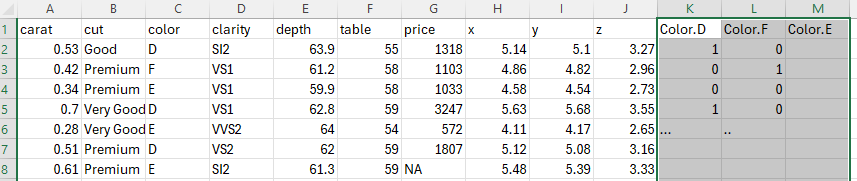

```r
#Frequncy table of variable "color"
table(dat$color)

#6 dummy variables to indicate variable "color"
```

```
   D    E    F    G    H    I    J
1497 2185 2114 2478 1807 1246  673
```

```r
library(tidyverse)
#%>%
dat.1 = dat %>% mutate(color.D = ifelse(color == "D", 1, 0),
color.E = ifelse(color == "E", 1, 0),
color.F = ifelse(color == "F", 1, 0),
color.G = ifelse(color == "G", 1, 0),
color.H = ifelse(color == "H", 1, 0),
color_I = ifelse(color == "I", 1, 0) )

#data$dummy_Ecolor = ifelse(data$color %in% c("E"), 1, 0)
```

```r
head(dat.1)
```

A data.frame: 6 × 16

|  | carat <dbl> | cut <chr> | color <chr> | clarity <chr> | depth <dbl> | table <dbl> | price <int> | x <dbl> | y <dbl> | z <dbl> | color.D <dbl> | color.E <dbl> | color.F <dbl> | color.G <dbl> | color.H <dbl> | color_I <dbl> |
| --- | --- | --- | --- | --- | --- | --- | --- | --- | --- | --- | --- | --- | --- | --- | --- | --- |
| 1 | 0.53 | Good | D | SI2 | 63.9 | 55 | 1318 | 5.14 | 5.10 | 3.27 | 1 | 0 | 0 | 0 | 0 | 0 |
| 2 | 0.42 | Premium | F | VS1 | 61.2 | 58 | 1103 | 4.86 | 4.82 | 2.96 | 0 | 0 | 1 | 0 | 0 | 0 |
| 3 | 0.34 | Premium | E | VS1 | 59.9 | 58 | 1033 | 4.58 | 4.54 | 2.73 | 0 | 1 | 0 | 0 | 0 | 0 |
| 4 | 0.70 | Very Good | D | VS1 | 62.8 | 59 | 3247 | 5.63 | 5.68 | 3.55 | 1 | 0 | 0 | 0 | 0 | 0 |
| 5 | 0.28 | Very Good | E | VVS2 | 64.0 | 54 | 572 | 4.11 | 4.17 | 2.65 | 0 | 1 | 0 | 0 | 0 | 0 |
| 6 | 0.51 | Premium | D | VS2 | 62.0 | 59 | 1807 | 5.12 | 5.08 | 3.16 | 1 | 0 | 0 | 0 | 0 | 0 |

```r
head(dat.1)
```

[output not shown]

```r
library(caret)

# Example dataset with categorical variable
data(iris)
head(iris)

# Create dummy variables for Species
dummies <- dummyVars(~ Species, data = iris)
iris.dummy <- predict(dummies, newdata = iris)

head(iris.dummy)

dummies <- dummyVars(~ ., data = iris)
iris.full <- predict(dummies, newdata = iris)

head(iris.full)
```

[output not shown]